# 498818_SDS_496_HW7

```python
import pandas as pd
import numpy as np

file_path = "/Users/aidanashrafi/Downloads/wine.csv"
data = pd.read_csv(file_path)
```

```python
print(data.head())

print(data.describe())

print((data).isna().sum())
```

```
   Type  Alcohol  Malic   Ash  Alcalinity  Magnesium  Phenols  Flavanoids  \
0     1    14.23   1.71  2.43        15.6        127     2.80        3.06
1     1    13.20   1.78  2.14        11.2        100     2.65        2.76
2     1    13.16   2.36  2.67        18.6        101     2.80        3.24
3     1    14.37   1.95  2.50        16.8        113     3.85        3.49
4     1    13.24   2.59  2.87        21.0        118     2.80        2.69

   Nonflavanoids  Proanthocyanins  Color   Hue  Dilution  Proline
0           0.28             2.29   5.64  1.04      3.92     1065
1           0.26             1.28   4.38  1.05      3.40     1050
2           0.30             2.81   5.68  1.03      3.17     1185
3           0.24             2.18   7.80  0.86      3.45     1480
4           0.39             1.82   4.32  1.04      2.93      735
             Type     Alcohol       Malic         Ash  Alcalinity   Magnesium  \
count  178.000000  178.000000  178.000000  178.000000  178.000000  178.000000
mean     1.938202   13.000618    2.336348    2.366517   19.494944   99.741573
std      0.775035    0.811827    1.117146    0.274344    3.339564   14.282484
min      1.000000   11.030000    0.740000    1.360000   10.600000   70.000000
25%      1.000000   12.362500    1.602500    2.210000   17.200000   88.000000
50%      2.000000   13.050000    1.865000    2.360000   19.500000   98.000000
75%      3.000000   13.677500    3.082500    2.557500   21.500000  107.000000
max      3.000000   14.830000    5.800000    3.230000   30.000000  162.000000

          Phenols  Flavanoids  Nonflavanoids  Proanthocyanins       Color  \
count  178.000000  178.000000     178.000000       178.000000  178.000000
mean     2.295112    2.029270       0.361854         1.590899    5.058090
std      0.625851    0.998859       0.124453         0.572359    2.318286
min      0.980000    0.340000       0.130000         0.410000    1.280000
25%      1.742500    1.205000       0.270000         1.250000    3.220000
50%      2.355000    2.135000       0.340000         1.555000    4.690000
75%      2.800000    2.875000       0.437500         1.950000    6.200000
max      3.880000    5.080000       0.660000         3.580000   13.000000

              Hue    Dilution      Proline
count  178.000000  178.000000   178.000000
mean     0.957449    2.611685   746.893258
std      0.228572    0.709990   314.907474
min      0.480000    1.270000   278.000000
25%      0.782500    1.937500   500.500000
50%      0.965000    2.780000   673.500000
```

[output cut: 46 more lines]

```
Type               0
Alcohol            0
Malic              0
Ash                0
Alcalinity         0
Magnesium          0
Phenols            0
Flavanoids         0
Nonflavanoids      0
Proanthocyanins    0
Color              0
Hue                0
Dilution           0
Proline            0
dtype: int64
```

### Problem 1. Download the wine data set under Modules on Canvas. The data set contains measurements for 178 wines produced in a specific area of Italy. We are interested in predicting the type of wine (Type – qualitative variable with 3 levels) given information on multiple quantitative predictors.

#### i. Calculate the sample covariance matrices between Alcohol and Phenols stratified by wine type. Do the 2 predictors have roughly the same covariance structure within each wine type?

```python
# Assuming 'Type' is the column indicating wine type
# Create subsets for each wine type
type_1 = data[data["Type"] == 1][["Alcohol", "Phenols"]]
type_2 = data[data["Type"] == 2][["Alcohol", "Phenols"]]
type_3 = data[data["Type"] == 3][["Alcohol", "Phenols"]]

# Calculate the covariance matrices
cov_type_1 = type_1.cov()
cov_type_2 = type_2.cov()
cov_type_3 = type_3.cov()

# Display the covariance matrices
print("Covariance matrix for Type 1:\n", cov_type_1, "\n")
print("Covariance matrix for Type 2:\n", cov_type_2, "\n")
print("Covariance matrix for Type 3:\n", cov_type_3, "\n")
```

```
Covariance matrix for Type 1:
           Alcohol   Phenols
Alcohol  0.213560  0.065897
Phenols  0.065897  0.114895

Covariance matrix for Type 2:
           Alcohol   Phenols
Alcohol  0.289406 -0.013590
Phenols -0.013590  0.297419

Covariance matrix for Type 3:
           Alcohol   Phenols
Alcohol  0.281156  0.039818
Phenols  0.039818  0.127428
```

Linear Discriminant Analysis (LDA) assumes identical covariance matrices for each class to produce linear decision boundaries. Here, we evaluate whether Alcohol and Phenols share a similar covariance structure across the three wine types.

#### ii. Split the data set into a training set and a test set. Fit a linear discriminant analysis model on the training set with only Alcohol and Phenols as predictors. Provide a matrix of the estimated group means. Calculate the confusion matrix and the misclassification rate on the test set.

```python
import numpy as np
from sklearn.model_selection import train_test_split
import statsmodels.api as sm
from sklearn.discriminant_analysis import LinearDiscriminantAnalysis
from sklearn.metrics import confusion_matrix, accuracy_score
train , test = train_test_split(data, test_size=0.2, random_state=0)


# Select features and target variable
X_train = train[["Alcohol", "Phenols"]]
y_train = train["Type"]
X_test = test[["Alcohol", "Phenols"]]
y_test = test["Type"]

# Fit the LDA model
lda = LinearDiscriminantAnalysis()
lda.fit(X_train, y_train)

# Provide the matrix of estimated group means
group_means = lda.means_
print("Estimated group means:\n", group_means)
print("\n")
# Make predictions on the test set
y_pred = lda.predict(X_test)

# Calculate the confusion matrix
conf_matrix = confusion_matrix(y_test, y_pred)
print("Confusion matrix:\n", conf_matrix)
print("\n")
# Calculate the misclassification rate
misclassification_rate = 1 - accuracy_score(y_test, y_pred)
print("Misclassification rate:", misclassification_rate)
```

```
Estimated group means:
 [[13.72466667  2.83311111]
 [12.26563636  2.21309091]
 [13.13404762  1.70285714]]


Confusion matrix:
 [[13  1  0]
 [ 2 14  0]
 [ 0  1  5]]


Misclassification rate: 0.11111111111111116
```

**The missclassification rate is 0.11111111111111116**

#### iii. Fit a linear discriminant analysis model on the training set with all available quantitative predictors. How many decision boundaries exist for this qualitative response variable and what form do they have? Calculate the confusion matrix and the misclassification rate on the test set. How does this classifier compare against the classifier in the previous part?

```python
# Select all quantitative predictors (excluding 'Type')
X_train_all = train.drop(columns=["Type"])
y_train_all = train["Type"]
X_test_all = test.drop(columns=["Type"])
y_test_all = test["Type"]

# Fit the LDA model using all predictors
lda_all = LinearDiscriminantAnalysis()
lda_all.fit(X_train_all, y_train_all)

num_boundaries = (3 * (3 - 1)) // 2
print("Number of decision boundaries:", num_boundaries)
print("\n")
# Make predictions on the test set
y_pred_all = lda_all.predict(X_test_all)

# Provide the confusion matrix
conf_matrix_all = confusion_matrix(y_test_all, y_pred_all)
print("Confusion matrix (all predictors):\n", conf_matrix_all)
print("\n")
# Calculate the misclassification rate
misclassification_rate_all = 1 - accuracy_score(y_test_all, y_pred_all)
print("Misclassification rate (all predictors):", misclassification_rate_all)
print("\n")
# Comparison with the previous model
print("Comparison:")
print("Misclassification rate with Alcohol and Phenols:", misclassification_rate)
print("Misclassification rate with all predictors:", misclassification_rate_all)
```

```
Number of decision boundaries: 3


Confusion matrix (all predictors):
 [[14  0  0]
 [ 1 15  0]
 [ 0  0  6]]


Misclassification rate (all predictors): 0.02777777777777779


Comparison:
Misclassification rate with Alcohol and Phenols: 0.11111111111111116
Misclassification rate with all predictors: 0.02777777777777779
```

For a Linear Discriminant Analysis (LDA) model with three classes, **three decision boundaries** are created. These boundaries are linear and separate each pair of classes, allowing LDA to distinguish among the three wine types based on the quantitative predictors.

Using all available quantitative predictors, the LDA model yields a misclassification rate of **0.0278**, meaning that approximately 2.78% of test samples were incorrectly classified.

In comparison, the previous classifier, which only used **Alcohol** and **Phenols** as predictors, had a higher misclassification rate of **0.1111**. Including all quantitative predictors thus significantly improved the model's performance, reducing the misclassification rate from 11.11% to 2.78%.

The addition of all quantitative predictors allowed the LDA model to capture more variance and separation between classes, leading to a better fit and more accurate predictions on the test set. This improvement highlights the importance of incorporating relevant predictors in the model for optimal classification accuracy.

#### iv. Fit a quadratic discriminant analysis model on the training set with all available quantitative predictors. How many decision boundaries exist for this qualitative response variable and what form do they have? Calculate the confusion matrix and the misclassification rate on the test set. How does this classifier compare against the classifiers in the previous parts?

```python
from sklearn.discriminant_analysis import QuadraticDiscriminantAnalysis

# Fit the QDA model using all predictors
qda = QuadraticDiscriminantAnalysis()
qda.fit(X_train_all, y_train_all)

# Number of decision boundaries for K = 3 classes
num_boundaries_qda = (3 * (3 - 1)) // 2
print("Number of decision boundaries (QDA):", num_boundaries_qda)

# Make predictions on the test set
y_pred_qda = qda.predict(X_test_all)

# Provide the confusion matrix
conf_matrix_qda = confusion_matrix(y_test_all, y_pred_qda)
print("Confusion matrix (QDA):\n", conf_matrix_qda)

# Calculate the misclassification rate
misclassification_rate_qda = 1 - accuracy_score(y_test_all, y_pred_qda)
print("Misclassification rate (QDA):", misclassification_rate_qda)

# Comparison with previous classifiers
print("\nComparison:")
print("Misclassification rate with Alcohol and Phenols (LDA):", misclassification_rate)
print("Misclassification rate with all predictors (LDA):", misclassification_rate_all)
print("Misclassification rate with all predictors (QDA):", misclassification_rate_qda)
```

```
Number of decision boundaries (QDA): 3
Confusion matrix (QDA):
 [[14  0  0]
 [ 0 16  0]
 [ 0  0  6]]
Misclassification rate (QDA): 0.0

Comparison:
Misclassification rate with Alcohol and Phenols (LDA): 0.11111111111111116
Misclassification rate with all predictors (LDA): 0.02777777777777779
Misclassification rate with all predictors (QDA): 0.0
```

For a Quadratic Discriminant Analysis (QDA) model with three classes, there are **three quadratic decision boundaries**. Unlike LDA, which uses linear boundaries, QDA’s decision boundaries are quadratic, allowing for more flexibility in separating classes when class covariances differ.

Using all available quantitative predictors, the QDA model yields a misclassification rate of **0.0**, indicating perfect classification on the test set.

- **LDA with Alcohol and Phenols**: Misclassification rate = **0.1111**
- **LDA with all predictors**: Misclassification rate = **0.0278**
- **QDA with all predictors**: Misclassification rate = **0.0**

By accounting for differences in covariance across classes, QDA achieved perfect accuracy on the test set, outperforming both LDA models. This highlights QDA's ability to handle more complex class boundaries when covariance structures vary between groups, as seen here.

### Problem 2. We are now interested in predicting the type of wine (Type – qualitative variable with 3 levels) by applying a fully non-parametric approach.

#### i. Fit a 1-nearest neighbor classifier on the training set with only Alcohol and Phenols as predictors. Calculate the confusion matrix and the misclassification rate on the test set.

```python
import warnings
warnings.filterwarnings("ignore", category=FutureWarning, module="sklearn.neighbors")

from sklearn.neighbors import KNeighborsClassifier
import matplotlib.pyplot as plt
X_train_knn = train[["Alcohol", "Phenols"]]
y_train_knn = train["Type"]
X_test_knn = test[["Alcohol", "Phenols"]]
y_test_knn = test["Type"]
# Fit a 1-nearest neighbor classifier
knn = KNeighborsClassifier(n_neighbors=1)
knn.fit(X_train_knn, y_train_knn)

# Make predictions on the test set
y_pred_knn = knn.predict(X_test_knn)

# Calculate the confusion matrix
conf_matrix = confusion_matrix(y_test_knn, y_pred_knn)
print("Confusion Matrix:\n", conf_matrix)

# Calculate the misclassification rate
misclassification_rate = 1 - accuracy_score(y_test_knn, y_pred_knn)
print("Misclassification Rate:", misclassification_rate)
```

```
Confusion Matrix:
 [[14  0  0]
 [ 2 13  1]
 [ 0  1  5]]
Misclassification Rate: 0.11111111111111116
```

For a 1-nearest neighbor (1-NN) classifier with three classes, the model uses only **Alcohol** and **Phenols** as predictors, yielding a misclassification rate of **0.1111** on the test set.

- **1-NN with Alcohol and Phenols**: Misclassification rate = **0.1111**

The 1-NN classifier captures some of the class distinctions but shows a higher misclassification rate compared to models that incorporate additional predictors. This result suggests that tuning, such as adjusting the number of neighbors or including more features, could improve classification performance.

#### ii. Fit k-nearest neighbors classifiers on the training set with only Alcohol and Phenols as predictors for k ranging from 1 to 20. Plot the misclassification rate on the test set as a function of k and select the optimal value of k. Report the confusion matrix and the misclassification rate on the test set for the optimal value of k. How does the misclassification rate for the optimal value of k compare against that in the previous part?

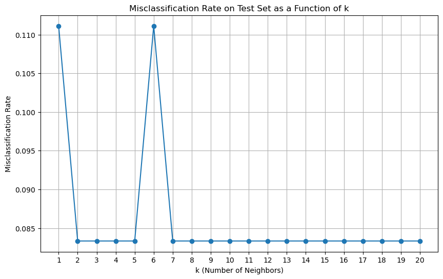

```
Confusion Matrix:
 [[14  0  0]
 [ 2 14  0]
 [ 0  1  5]]
Misclassification Rate: 0.08333333333333337
```

```python
import warnings
warnings.filterwarnings("ignore", category=FutureWarning, module="sklearn.neighbors")


misclassification_rates_knn = []

# Loop over k values from 1 to 20
for k in range(1, 21):
    # Fit k-nearest neighbor classifier with current k
    knn = KNeighborsClassifier(n_neighbors=k)
    knn.fit(X_train, y_train)

    # Make predictions on the test set
    y_pred = knn.predict(X_test)

    # Calculate the misclassification rate and add it to the list
    misclassification_rate = 1 - accuracy_score(y_test, y_pred)
    misclassification_rates_knn.append(misclassification_rate)

plt.figure(figsize=(10, 6))
plt.plot(range(1, 21), misclassification_rates_knn, marker='o', linestyle='-')
plt.xlabel('k (Number of Neighbors)')
plt.ylabel('Misclassification Rate')
plt.title('Misclassification Rate on Test Set as a Function of k')
plt.xticks(range(1, 21))
plt.grid()
plt.show()


optimal_knn = KNeighborsClassifier(n_neighbors=2)
optimal_knn.fit(X_train,y_train)
y_pred_optimal =optimal_knn.predict(X_test)

conf_matrix = confusion_matrix(y_test, y_pred_optimal)
print("Confusion Matrix:\n", conf_matrix)

# Calculate the misclassification rate
misclassification_rate = 1 - accuracy_score(y_test, y_pred_optimal)
print("Misclassification Rate:", misclassification_rate)
```

For k-nearest neighbors classifiers using only **Alcohol** and **Phenols** as predictors, the optimal value of **k** is **2**, as it produces the lowest misclassification rate on the test set at the earliest point.

- **Optimal k = 2**: Misclassification rate = **0.083333** which is **lower** than the misclassification rate with k = 1 which was **0.11111**.

This result shows that using **k = 2** improves the classifier’s performance compared to k = 1, as it yields a lower misclassification rate on the test set. This highlights the benefit of adjusting the number of neighbors in k-NN to optimize classification accuracy.

iii. Fit a 1-nearest neighbor classifier on the training set with all available predictors. Calculate the confusion matrix and the misclassification rate on the test set. How does the misclassification rate compare against that in part i?

```python
import warnings
warnings.filterwarnings("ignore", category=FutureWarning, module="sklearn.neighbors")



# Select all quantitative predictors (excluding 'Type')
X_train_all = train.drop(columns=["Type"])
y_train_all = train["Type"]
X_test_all = test.drop(columns=["Type"])
y_test_all = test["Type"]

# Fit a 1-nearest neighbor classifier
knn_all = KNeighborsClassifier(n_neighbors=1)
knn_all.fit(X_train_all, y_train_all)

# Make predictions on the test set
y_pred_knn_all = knn_all.predict(X_test_all)

# Calculate the confusion matrix
conf_matrix = confusion_matrix(y_test_all, y_pred_knn_all)
print("Confusion Matrix:\n", conf_matrix)

# Calculate the misclassification rate
misclassification_rate = 1 - accuracy_score(y_test_all, y_pred_knn_all)
print("Misclassification Rate:", misclassification_rate)
```

```
Confusion Matrix:
 [[13  1  0]
 [ 1 12  3]
 [ 1  2  3]]
Misclassification Rate: 0.2222222222222222
```

For a 1-nearest neighbor (1-NN) classifier using all available predictors, the model yields a misclassification rate of **0.2222** on the test set.

- **1-NN with Alcohol and Phenols**: Misclassification rate = **0.1111**
- **1-NN with All Predictors**: Misclassification rate = **0.2222**

This result shows that including all predictors increased the misclassification rate compared to using only Alcohol and Phenols. This suggests that adding more predictors may have introduced noise or reduced the model’s ability to generalize effectively on the test set.

#### iv. Fit k-nearest neighbors classifiers on the training set with all available predictors for k ranging from 1 to 20. Plot the misclassification rate on the test set as a function of k and select the optimal value of k. Report the confusion matrix and the misclassification rate on the test set for the optimal value of k. How does the optimal value of k compare against that in part ii? How does the misclassification rate for the optimal value of k compare against those in parts ii and iii?

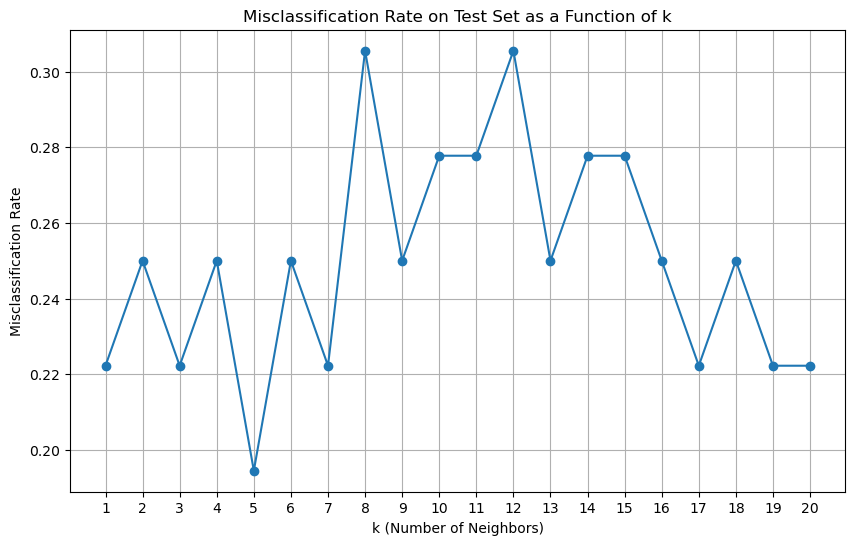

```
Confusion Matrix:
 [[13  0  1]
 [ 0 14  2]
 [ 2  2  2]]
Misclassification Rate: 0.19444444444444442
```

```python
import warnings
from sklearn.neighbors import KNeighborsClassifier

# Suppress FutureWarning
with warnings.catch_warnings():
    warnings.simplefilter("ignore", category=FutureWarning)

    # Place your k-nearest neighbors code here
    misclassification_rates_knn = []
    for k in range(1, 21):
        knn_all = KNeighborsClassifier(n_neighbors=k)
        knn_all.fit(X_train_all, y_train_all)

        # Make predictions on the test set
        y_pred_knn_all = knn_all.predict(X_test_all)

        # Calculate the misclassification rate and add it to the list
        misclassification_rate = 1 - accuracy_score(y_test_all, y_pred_knn_all)
        misclassification_rates_knn.append(misclassification_rate)
# Plot the misclassification rate as a function of k
plt.figure(figsize=(10, 6))
plt.plot(range(1, 21), misclassification_rates_knn, marker='o', linestyle='-')
plt.xlabel('k (Number of Neighbors)')
plt.ylabel('Misclassification Rate')
plt.title('Misclassification Rate on Test Set as a Function of k')
plt.xticks(range(1, 21))
plt.grid()
plt.show()


optimal_knn_all = KNeighborsClassifier(n_neighbors=5)
optimal_knn_all.fit(X_train_all,y_train_all)
y_pred_optimal_all =optimal_knn_all.predict(X_test_all)

conf_matrix = confusion_matrix(y_test_all, y_pred_optimal_all)
print("Confusion Matrix:\n", conf_matrix)

# Calculate the misclassification rate
misclassification_rate = 1 - accuracy_score(y_test_all, y_pred_optimal_all)
print("Misclassification Rate:", misclassification_rate)
```

For k-nearest neighbors classifiers using all available predictors, the optimal value of **k** is **5**, as it yields the lowest misclassification rate on the test set.

- **Optimal k (all predictors) = 5**: Misclassification rate = **0.1944**
- **Optimal k (Alcohol and Phenols only) = 2**: Misclassification rate = **0.0833**
- **k = 1 (all predictors)**: Misclassification rate = **0.2222**

The misclassification rate for **k = 5** is lower than that of **k = 1** when using all predictors. However, it is higher than the misclassification rate achieved with only Alcohol and Phenols and **k = 2**. This suggests that while a more flexible model can improve accuracy, including all predictors does not necessarily guarantee better generalization on the test set.